# The Diabetes Project

Vivian Do, Bethany Wang

2023-06-05

### Update Notes:

#### 6-4 Bethany

- Layout the project
- Did initial version of EDA

#### 6-6 Vivian

- Modified some initial steps of checking and classifying features
- Define response variable and convert to binary levels
- Separate numerical and categorical variables
- Added boxplots of numerical predictors and the target variable

#### 6-7 Bethany

- Summarized and analyzed the degenerated features
- Completed histograms for all the other categorical features
- Added another implementation of the boxplots in section 1.9
- Did most of the data preprocessing
- Not sure why the data imputing does not work?
- Question/suggetion: move the factoring the categorical variables to preprocessing section

#### 6-8 Bethany

- Cleaned up and reorganized EDA
- Minor fixes in data preprocessing

#### 6-12 Vivian

- Create frequeny counts, proportions for each categorical variable vs. response
- Create barcharts w/ proportions for all categorical variables + observed findings.
- Fix data import to replace all “?” string with NA
- Perform feature deletions (see reasonings below)
- Convert categorical variables into dummies. Create new dataframe w/ dummies called ‘df_dummies’
- Perform centering/scaling
- Add Logistic regression, LDA, Penalized LogReg, and NSC models
- Create confusion matrix, plot ROC curves, compare AUC

#### 6-13 Bethany

- Reorganized EDA
- Organized and cleaned up data preprocessing
- Deleted more low variance/skewed predictors
- Added step 2.4 “remove outliers”
- Added step 2.9 “PCA Analysis”
- Added functions to calculate a model’s performance metrics
- Completed the linear classification models: LR, LDA, GLMN, NSC
- Added one nonlinear classification models: MDA
- Completed the models evaluation section

### 1. Exploratory Data Analysis

#### **1.1 Import and check the Data**

```r
#Read in data, replace "?" with NA values
df <- read.csv(file = "diabetic_data.csv", na.strings=c("?"))
dim(df)
```

```
## [1] 101766     50
```

```r
str(df)
```

```
## 'data.frame':    101766 obs. of  50 variables:
##  $ encounter_id            : int  2278392 149190 64410 500364 16680 35754 55842 63768 12522 15738 ...
##  $ patient_nbr             : int  8222157 55629189 86047875 82442376 42519267 82637451 84259809 114882984 48330783 63555939 ...
##  $ race                    : chr  "Caucasian" "Caucasian" "AfricanAmerican" "Caucasian" ...
##  $ gender                  : chr  "Female" "Female" "Female" "Male" ...
##  $ age                     : chr  "[0-10)" "[10-20)" "[20-30)" "[30-40)" ...
##  $ weight                  : chr  NA NA NA NA ...
##  $ admission_type_id       : int  6 1 1 1 1 2 3 1 2 3 ...
##  $ discharge_disposition_id: int  25 1 1 1 1 1 1 1 1 3 ...
##  $ admission_source_id     : int  1 7 7 7 7 2 2 7 4 4 ...
##  $ time_in_hospital        : int  1 3 2 2 1 3 4 5 13 12 ...
##  $ payer_code              : chr  NA NA NA NA ...
##  $ medical_specialty       : chr  "Pediatrics-Endocrinology" NA NA NA ...
##  $ num_lab_procedures      : int  41 59 11 44 51 31 70 73 68 33 ...
##  $ num_procedures          : int  0 0 5 1 0 6 1 0 2 3 ...
```

[output cut: 36 more lines]

- There are 101766 data records with 50 features

#### **1.2 Convert categorical variables into factors**

- All feature that are recorded as chr type are categorical variables
- admission_type_id, discharge_disposition_id, admission_source_id are recorded as int, but should be taken as categorical variables.

```r
#Convert categorical variables into factors (according to Table 1 https://www.hindawi.com/journals/bmri/2014/781670/tab1/)
df[sapply(df, is.character)] <- lapply(df[sapply(df, is.character)],
                                       as.factor)

df$admission_type_id <- as.factor(df$admission_type_id)
df$discharge_disposition_id <- as.factor(df$discharge_disposition_id)
df$admission_source_id <- as.factor(df$admission_source_id)
```

- All categorical variables have been concerted into factors

#### **1.3 Classify features**

- Subset numerical and categorical features

```r
# Subset numerical and categorical features into new data frames
library(dplyr)
df_num <- df %>%  select_if(is.integer)
df_num <- subset(df_num, select = -c(encounter_id, patient_nbr))

df_cat <- df %>% select_if(is.factor)

# Show numerical variables
cat("These are the numerical features:\n", colnames(df_num), "\n\n")
```

```
## These are the numerical features:
##  time_in_hospital num_lab_procedures num_procedures num_medications number_outpatient number_emergency number_inpatient number_diagnoses
```

```r
# Show categorical variables
cat("These are the categorical features:\n", colnames(df_cat), "\n\n")
```

```
## These are the categorical features:
##  race gender age weight admission_type_id discharge_disposition_id admission_source_id payer_code medical_specialty diag_1 diag_2 diag_3 max_glu_serum A1Cresult metformin repaglinide nateglinide chlorpropamide glimepiride acetohexamide glipizide glyburide tolbutamide pioglitazone rosiglitazone ac…
```

```r
library(dplyr)
n_distinct(df$encounter_id)
```

```
## [1] 101766
```

```r
n_distinct(df$patient_nbr)
```

```
## [1] 71518
```

- Out of 101766 encounters, there were 71518 (new) patients admitted while 30248 encounters were readmissions.
- After printing the unique values, we see encounter_id and patient_nbr are just some identifiers, not useful features. We do not need to further explore them.

#### **1.4 Explore and revalue the response variable**

- We use “readmitted” as our response variable

```r
# Show readmission counts
table(df$readmitted)
```

```
##
##   <30   >30    NO
## 11357 35545 54864
```

```r
library(plyr)
# Combine all readmissions
revalue(df$readmitted, c("<30" = "YES")) -> df$readmitted
revalue(df$readmitted, c(">30" = "YES")) -> df$readmitted

# Show readmission counts using binary levels
table(df$readmitted)
```

```
##
##   YES    NO
## 46902 54864
```

- After revalue response “<30” and “>30” to “YES”, there are 46902 instances of “YES” and 54864 instances of “NO”

#### **1.5 Check for missing values**

```r
# Check null values
#Show null counts
null_counts <- sort(colSums(is.na(df)), decreasing=TRUE)
head(null_counts, 10)
```

```
##            weight medical_specialty        payer_code              race
##             98569             49949             40256              2273
##            diag_3            diag_2            diag_1      encounter_id
##              1423               358                21                 0
##       patient_nbr            gender
##                 0                 0
```

```r
#Show proportion of null counts
head(prop.table(null_counts), 10)
```

```
##            weight medical_specialty        payer_code              race
##      0.5111200991      0.2590057506      0.2087436284      0.0117864236
##            diag_3            diag_2            diag_1      encounter_id
##      0.0073788301      0.0018563747      0.0001088935      0.0000000000
##       patient_nbr            gender
##      0.0000000000      0.0000000000
```

#### **1.6 Check degenerated features**

```r
library(caret)

degenerateCols <- nearZeroVar(df)
length(degenerateCols)
```

```
## [1] 18
```

```r
degenerateColNames <- colnames(df[degenerateCols])
degenerateColNum <- length(degenerateColNames)

cat("These are ", degenerateColNum, " degenerated predictors:\n", degenerateColNames)
```

```
## These are  18  degenerated predictors:
##  max_glu_serum repaglinide nateglinide chlorpropamide glimepiride acetohexamide tolbutamide acarbose miglitol troglitazone tolazamide examide citoglipton glyburide.metformin glipizide.metformin glimepiride.pioglitazone metformin.rosiglitazone metformin.pioglitazone
```

```r
#subset the degenerated predictors
df_degenerated <- df[,degenerateColNames]

colnames(df_degenerated)
```

```
##  [1] "max_glu_serum"            "repaglinide"
##  [3] "nateglinide"              "chlorpropamide"
##  [5] "glimepiride"              "acetohexamide"
##  [7] "tolbutamide"              "acarbose"
##  [9] "miglitol"                 "troglitazone"
## [11] "tolazamide"               "examide"
## [13] "citoglipton"              "glyburide.metformin"
## [15] "glipizide.metformin"      "glimepiride.pioglitazone"
## [17] "metformin.rosiglitazone"  "metformin.pioglitazone"
```

```r
# Check the distribution of the degenerated predictors
summary(df_degenerated)
```

```
##  max_glu_serum repaglinide     nateglinide     chlorpropamide  glimepiride
##  >200: 1485    Down  :    45   Down  :    11   Down  :     1   Down  :  194
##  >300: 1264    No    :100227   No    :101063   No    :101680   No    :96575
##  None:96420    Steady:  1384   Steady:   668   Steady:    79   Steady: 4670
##  Norm: 2597    Up    :   110   Up    :    24   Up    :     6   Up    :  327
##  acetohexamide   tolbutamide       acarbose        miglitol
##  No    :101765   No    :101743   Down  :     3   Down  :     5
##  Steady:     1   Steady:    23   No    :101458   No    :101728
##                                  Steady:   295   Steady:    31
##                                  Up    :    10   Up    :     2
##  troglitazone     tolazamide     examide     citoglipton glyburide.metformin
##  No    :101763   No    :101727   No:101766   No:101766   Down  :     6
##  Steady:     3   Steady:    38                           No    :101060
##                  Up    :     1                           Steady:   692
##                                                          Up    :     8
##  glipizide.metformin glimepiride.pioglitazone metformin.rosiglitazone
##  No    :101753       No    :101765            No    :101764
##  Steady:    13       Steady:     1            Steady:     2
##
##
##  metformin.pioglitazone
##  No    :101765
##  Steady:     1
##
##
```

- There are 18 degenerated predictors that show near-zero variance.

#### **1.7 Statistics of the numerical variables**

```r
summary(df_num)
```

```
##  time_in_hospital num_lab_procedures num_procedures num_medications
##  Min.   : 1.000   Min.   :  1.0      Min.   :0.00   Min.   : 1.00
##  1st Qu.: 2.000   1st Qu.: 31.0      1st Qu.:0.00   1st Qu.:10.00
##  Median : 4.000   Median : 44.0      Median :1.00   Median :15.00
##  Mean   : 4.396   Mean   : 43.1      Mean   :1.34   Mean   :16.02
##  3rd Qu.: 6.000   3rd Qu.: 57.0      3rd Qu.:2.00   3rd Qu.:20.00
##  Max.   :14.000   Max.   :132.0      Max.   :6.00   Max.   :81.00
##  number_outpatient number_emergency  number_inpatient  number_diagnoses
##  Min.   : 0.0000   Min.   : 0.0000   Min.   : 0.0000   Min.   : 1.000
##  1st Qu.: 0.0000   1st Qu.: 0.0000   1st Qu.: 0.0000   1st Qu.: 6.000
##  Median : 0.0000   Median : 0.0000   Median : 0.0000   Median : 8.000
##  Mean   : 0.3694   Mean   : 0.1978   Mean   : 0.6356   Mean   : 7.423
##  3rd Qu.: 0.0000   3rd Qu.: 0.0000   3rd Qu.: 1.0000   3rd Qu.: 9.000
##  Max.   :42.0000   Max.   :76.0000   Max.   :21.0000   Max.   :16.000
```

#### **1.8 Correlations of the numerical variables**

- Find Correlations of numerical features

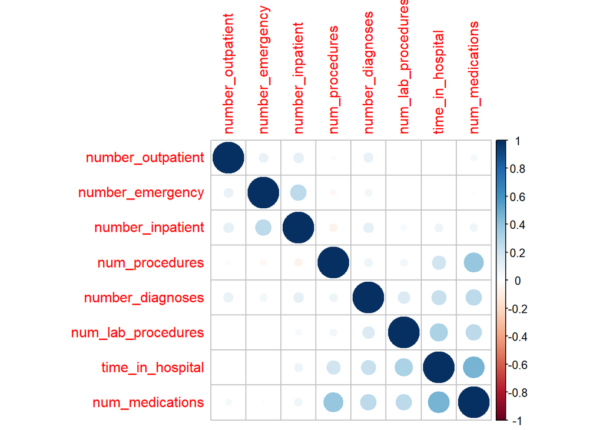

```r
library(corrplot)
correlations <- cor(df_num)

# Correlation plot
corrplot(correlations, order = "hclust")
```

#### **1.9 Distribution of the numerical variables**

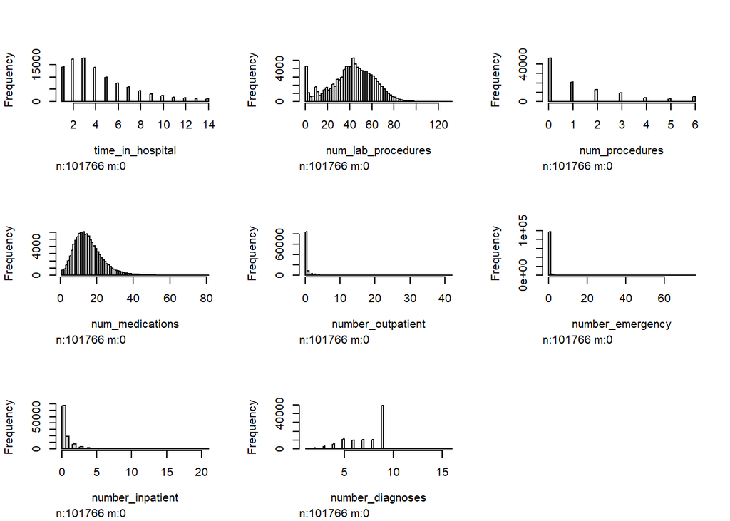

```r
library(Hmisc)
hist.data.frame(df_num)
```

#### **1.10 Explore the relationship between the numerical predictors and the predicted variable**

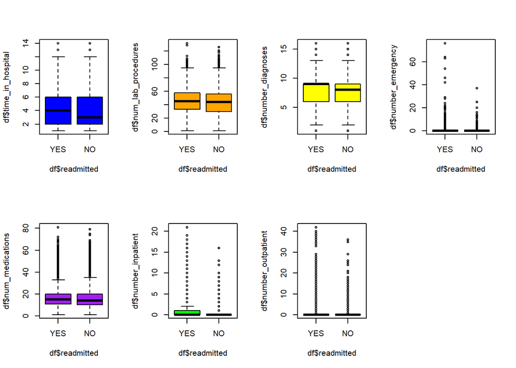

```r
par(mfrow = c(2,4))

boxplot(df$time_in_hospital ~ df$readmitted, col="blue")
boxplot(df$num_lab_procedures ~ df$readmitted, col="orange")
boxplot(df$number_diagnoses ~ df$readmitted, col="yellow")

boxplot(df$number_emergency ~ df$readmitted, col="cyan")
boxplot(df$num_medications ~ df$readmitted, col="purple")
boxplot(df$number_inpatient ~ df$readmitted, col="green")
boxplot(df$number_outpatient ~ df$readmitted, col="lightblue")
```

Patients who are readmitted, in general

- Spend more time in the hospital
- Have more inpatient visits in the year preceding the encounter
- Have more diagnoses entered to the system during their encounter.

#### **1.11 Distribution of the categorical variables**

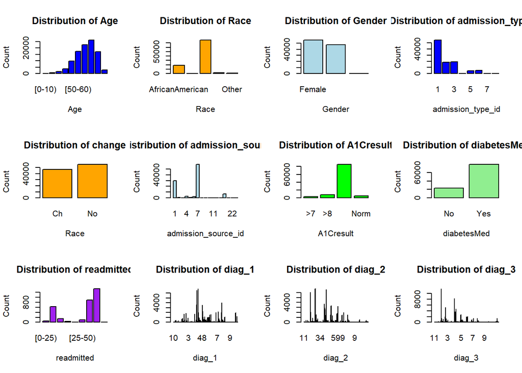

```r
par(mfrow = c(3,4))

barplot(table(df$age), main="Distribution of Age",
        xlab="Age", ylab="Count", col="blue")

barplot(table(df$race), main="Distribution of Race",
        xlab="Race", ylab="Count", col="orange")

barplot(table(df$gender), main="Distribution of Gender",
        xlab="Gender", ylab="Count", col="lightblue")

barplot(table(df$admission_type_id), main="Distribution of admission_type_id",
        xlab="admission_type_id", ylab="Count", col="blue")

barplot(table(df$change), main="Distribution of change",
        xlab="Race", ylab="Count", col="orange")

barplot(table(df$admission_source_id), main="Distribution of admission_source_id",
        xlab="admission_source_id", ylab="Count", col="lightblue")

barplot(table(df$A1Cresult), main="Distribution of A1Cresult",
        xlab="A1Cresult", ylab="Count", col="green")

barplot(table(df$diabetesMed), main="Distribution of diabetesMed",
        xlab="diabetesMed", ylab="Count", col="lightgreen")

barplot(table(df$weight), main="Distribution of readmitted",
        xlab="readmitted", ylab="Count", col="purple")

barplot(table(df$diag_1), main="Distribution of diag_1",
        xlab="diag_1", ylab="Count", col="orange")

barplot(table(df$diag_2), main="Distribution of diag_2",
        xlab="diag_2", ylab="Count", col="lightblue")

barplot(table(df$diag_3), main="Distribution of diag_3",
        xlab="diag_3", ylab="Count", col="green")
```

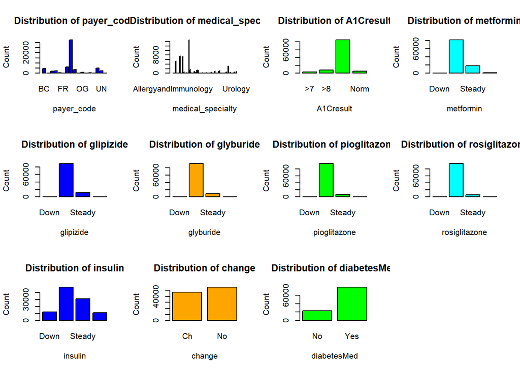

```r
par(mfrow = c(3,4))

barplot(table(df$payer_code), main="Distribution of payer_code",
        xlab="payer_code", ylab="Count", col="blue")

barplot(table(df$medical_specialty), main="Distribution of medical_specialty",
        xlab="medical_specialty", ylab="Count", col="orange")

barplot(table(df$A1Cresult), main="Distribution of A1Cresult",
        xlab="A1Cresult", ylab="Count", col="green")

barplot(table(df$metformin), main="Distribution of metformin",
        xlab="metformin", ylab="Count", col="cyan")

barplot(table(df$glipizide), main="Distribution of glipizide",
        xlab="glipizide", ylab="Count", col="blue")

barplot(table(df$glyburide), main="Distribution of glyburide",
        xlab="glyburide", ylab="Count", col="orange")

barplot(table(df$pioglitazone), main="Distribution of pioglitazone",
        xlab="pioglitazone", ylab="Count", col="green")

barplot(table(df$rosiglitazone), main="Distribution of rosiglitazone",
        xlab="rosiglitazone", ylab="Count", col="cyan")

barplot(table(df$insulin), main="Distribution of insulin",
        xlab="insulin", ylab="Count", col="blue")

barplot(table(df$change), main="Distribution of change",
        xlab="change", ylab="Count", col="orange")

barplot(table(df$diabetesMed), main="Distribution of diabetesMed",
        xlab="diabetesMed", ylab="Count", col="green")

#barplot(table(df$medical_specialty), main="Distribution of Race", xlab="Race", ylab="Count", col="cyan")
```

#### **1.12 Explore the relationship between the categorical predictors and the predicted variable**

```r
# Frequency counts
ct_race <- table(df$readmitted, df$race)
ct_gender <- table(df$readmitted, df$gender)
ct_age <- table(df$readmitted, df$age)
ct_weight <- table(df$readmitted, df$weight)
ct_admissionType <- table(df$readmitted, df$admission_type_id)
ct_dischargeID <- table(df$readmitted, df$discharge_disposition_id)
ct_admissionSource <- table(df$readmitted, df$admission_source_id)
ct_payerCode <- table(df$readmitted, df$payer_code)
ct_medSpec <- table(df$readmitted, df$medical_specialty)
ct_A1C <- table(df$readmitted, df$A1Cresult)
ct_metf <- table(df$readmitted, df$metformin)
ct_glipz <- table(df$readmitted, df$glipizide)
ct_glyb <- table(df$readmitted, df$glyburide)
ct_piog <- table(df$readmitted, df$pioglitazone)
ct_rosig <- table(df$readmitted, df$rosiglitazone)
ct_insulin <- table(df$readmitted, df$insulin)
ct_change <- table(df$readmitted, df$change)
ct_diabMeds <- table(df$readmitted, df$diabetesMed)

# Create contingency tables showing proportions
ct_race1 <- prop.table(table(df$readmitted, df$race),2)
ct_gender1 <- prop.table(table(df$readmitted, df$gender),2)
ct_age1 <- prop.table(table(df$readmitted, df$age),2)
ct_weight1 <- prop.table(table(df$readmitted, df$weight),2)
ct_admissionType1 <- prop.table(table(df$readmitted, df$admission_type_id),2)
ct_dischargeID1 <- prop.table(table(df$readmitted, df$discharge_disposition_id),2)
ct_admissionSource1 <- prop.table(table(df$readmitted, df$admission_source_id),2)
ct_payerCode1 <- prop.table(table(df$readmitted, df$payer_code),2)
ct_medSpec1 <- prop.table(table(df$readmitted, df$medical_specialty),2)
ct_A1C1 <- prop.table(table(df$readmitted, df$A1Cresult),2)
ct_metf1 <- prop.table(table(df$readmitted, df$metformin),2)
ct_glipz1 <- prop.table(table(df$readmitted, df$glipizide),2)
ct_glyb1 <- prop.table(table(df$readmitted, df$glyburide),2)
ct_piog1 <- prop.table(table(df$readmitted, df$pioglitazone),2)
ct_rosig1 <- prop.table(table(df$readmitted, df$rosiglitazone),2)
ct_insulin1 <- prop.table(table(df$readmitted, df$insulin),2)
ct_change1 <- prop.table(table(df$readmitted, df$change),2)
ct_diabMeds1 <- prop.table(table(df$readmitted, df$diabetesMed),2)
```

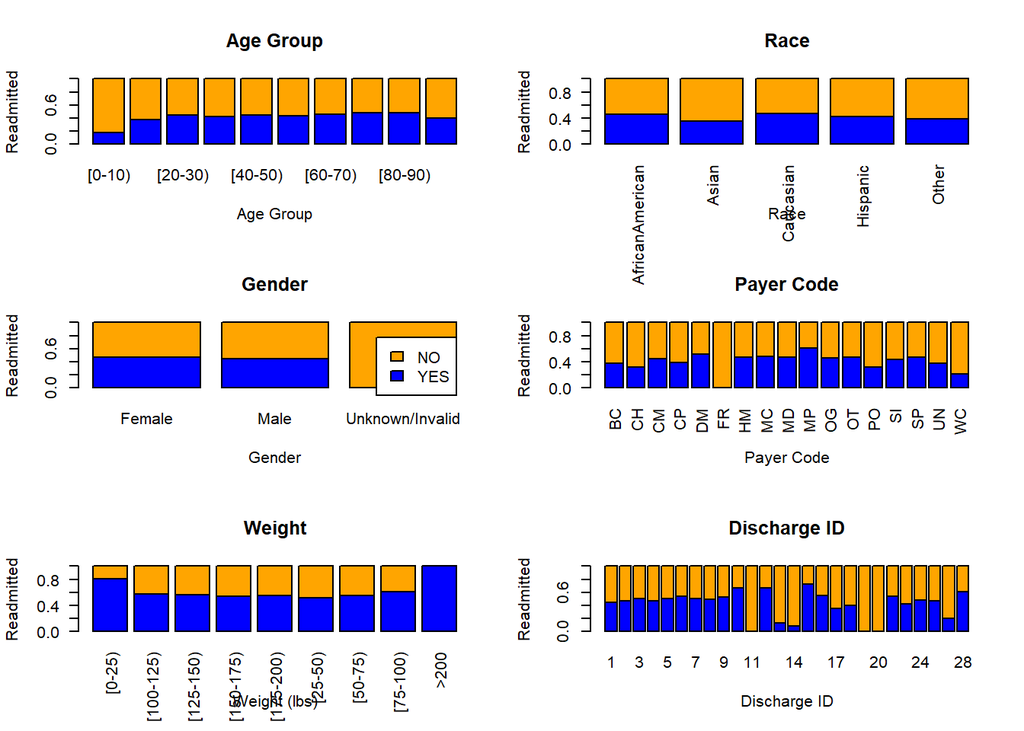

```r
## Create barplots ##
# Patient Demographics (Legend removed for individual graphs where bars would be blocked)
par(mfrow=c(3,2))
barplot(ct_age1,main="Age Group",xlab="Age Group",ylab="Readmitted",col=c("blue", "orange"))
barplot(ct_race1,main="Race",xlab="Race",ylab="Readmitted",col=c("blue", "orange"),las=2)
barplot(ct_gender1,main="Gender",xlab="Gender",ylab="Readmitted",col=c("blue", "orange"),legend=rownames(ct_gender1))
barplot(ct_payerCode1,main="Payer Code",xlab="Payer Code",ylab="Readmitted",col=c("blue", "orange"),las=2)
barplot(ct_weight1,main="Weight",xlab="Weight (lbs)",ylab="Readmitted",col=c("blue", "orange"),las=2)
barplot(ct_dischargeID1,main="Discharge ID",xlab="Discharge ID",ylab="Readmitted",col=c("blue", "orange"))
```

- Race: Asians were disproportionately less likely to be readmitted.
- Weight: Patients weighing 0-25 or >200 lbs were disproportionately more likely to be readmitted.
- Discharge ID: Discharge IDs 11, 19, and 20 were disproportionately less likely to be readmitted. Patients with discharge IDs 10,12,15 were disproportionately more likely to be readmitted.

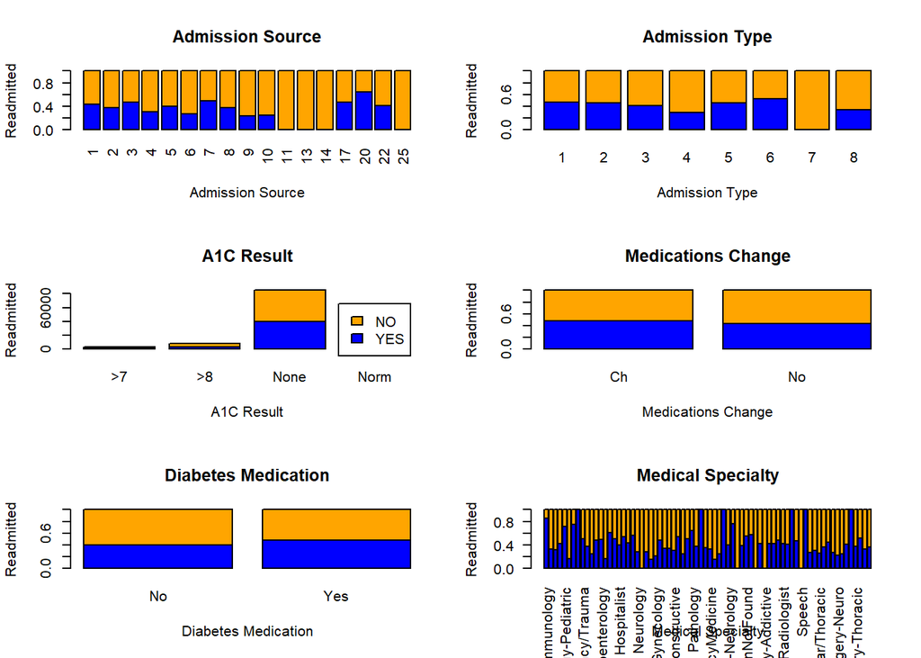

```r
# General encounter information
par(mfrow=c(3,2))
barplot(ct_admissionSource1,main="Admission Source",xlab="Admission Source",ylab="Readmitted",col=c("blue", "orange"),las=2)
barplot(ct_admissionType1,main="Admission Type",xlab="Admission Type",ylab="Readmitted",col=c("blue", "orange"))
barplot(ct_A1C,main="A1C Result",xlab="A1C Result",ylab="Readmitted",col=c("blue", "orange"),legend=rownames(ct_A1C))
barplot(ct_change1,main="Medications Change",xlab="Medications Change",ylab="Readmitted",col=c("blue", "orange"))
barplot(ct_diabMeds1,main="Diabetes Medication",xlab="Diabetes Medication",ylab="Readmitted",col=c("blue", "orange"))
barplot(ct_medSpec1,main="Medical Specialty",xlab="Medical Specialty",ylab="Readmitted",col=c("blue", "orange"),las=2)
```

- Admission Source: Admission sources 11, 13, 14, 25 less likely to be readmitted.
- Admission Type: Admission type 7 less likely to be readmitted.
- Medical Specialty: Patients admitted by certain medical specialities were less likely to be readmitted, such as Speech, Psychiatry, and Neurology.

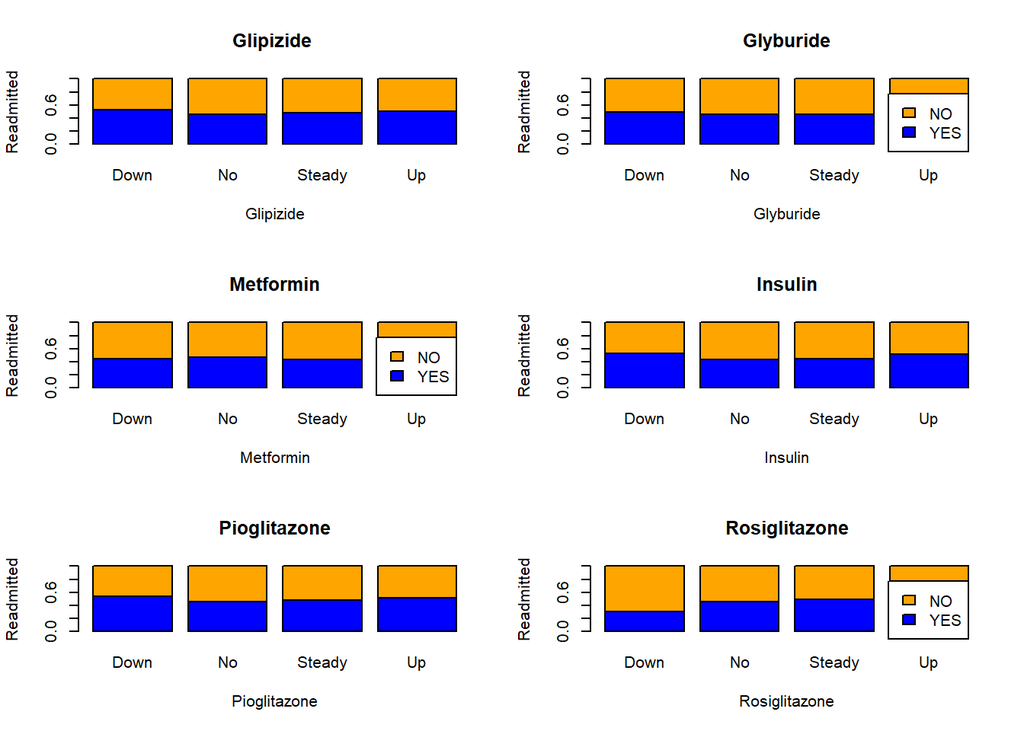

```r
# All medications
par(mfrow=c(3,2))
barplot(ct_glipz1,main="Glipizide ",xlab="Glipizide",ylab="Readmitted",col=c("blue", "orange"))
barplot(ct_glyb1,main="Glyburide",xlab="Glyburide",ylab="Readmitted",col=c("blue", "orange"),legend=rownames(ct_glyb1))
barplot(ct_metf1,main="Metformin",xlab="Metformin",ylab="Readmitted",col=c("blue", "orange"),legend=rownames(ct_metf1))
barplot(ct_insulin1,main="Insulin",xlab="Insulin",ylab="Readmitted",col=c("blue", "orange"))
barplot(ct_piog1,main="Pioglitazone",xlab="Pioglitazone",ylab="Readmitted",col=c("blue", "orange"))
barplot(ct_rosig1,main="Rosiglitazone",xlab="Rosiglitazone",ylab="Readmitted",col=c("blue", "orange"),legend=rownames(ct_rosig1))
```

- Patients who were prescribed a decreased dosage of rosiglitazone were less likely to be readmitted.
- Besides this, no other significant differences for the change in/prescription of drugs were observed.

### 2. Data Preprocessing

#### **2.1 Filter out degenerated predictors**

```r
# Use nearZeroVar function to filter out low variance features
df_pr <- df[, -degenerateCols]
dim(df_pr)
```

```
## [1] 101766     32
```

```r
colnames(df_pr)
```

```
##  [1] "encounter_id"             "patient_nbr"
##  [3] "race"                     "gender"
##  [5] "age"                      "weight"
##  [7] "admission_type_id"        "discharge_disposition_id"
##  [9] "admission_source_id"      "time_in_hospital"
## [11] "payer_code"               "medical_specialty"
## [13] "num_lab_procedures"       "num_procedures"
## [15] "num_medications"          "number_outpatient"
## [17] "number_emergency"         "number_inpatient"
## [19] "diag_1"                   "diag_2"
## [21] "diag_3"                   "number_diagnoses"
## [23] "A1Cresult"                "metformin"
## [25] "glipizide"                "glyburide"
## [27] "pioglitazone"             "rosiglitazone"
## [29] "insulin"                  "change"
## [31] "diabetesMed"              "readmitted"
```

- 18 degenerated predictors that show near-zero variance have been removed. 32 columns are left in the dataset.

#### **2.2 Delete other useless features**

```r
# df_pr <- subset(df_pr, select = -c(encounter_id, patient_nbr,weight,medical_specialty,payer_code,diag_1,diag_2,diag_3,race))

df_pr <- subset(df_pr, select = -c(encounter_id, patient_nbr, diag_1, diag_2,diag_3, race, number_emergency, number_outpatient, number_inpatient, A1Cresult, glyburide, pioglitazone, pioglitazone, rosiglitazone, glipizide))

dim(df_pr)
```

```
## [1] 101766     18
```

- After this step, 18 columns are left in the data frame.

#### **2.3 Handle missing values**

- weight, medical_specialty, and payer_code contain large portion of missing values

```r
# Check null values
#Show null counts
null_counts <- sort(colSums(is.na(df_pr)), decreasing=TRUE)
head(null_counts, 5)
```

```
##            weight medical_specialty        payer_code            gender
##             98569             49949             40256                 0
##               age
##                 0
```

```r
#Show proportion of null counts
head(prop.table(null_counts), 5)
```

```
##            weight medical_specialty        payer_code            gender
##         0.5221535         0.2645968         0.2132497         0.0000000
##               age
##         0.0000000
```

```r
df_pr <- subset(df_pr, select = -c(weight,medical_specialty, payer_code))

dim(df_pr)
```

```
## [1] 101766     15
```

```r
sum(is.na(df_pr))
```

```
## [1] 0
```

```r
colnames(df_pr)
```

```
##  [1] "gender"                   "age"
##  [3] "admission_type_id"        "discharge_disposition_id"
##  [5] "admission_source_id"      "time_in_hospital"
##  [7] "num_lab_procedures"       "num_procedures"
##  [9] "num_medications"          "number_diagnoses"
## [11] "metformin"                "insulin"
## [13] "change"                   "diabetesMed"
## [15] "readmitted"
```

- After this step, 15 columns are left in the data frame.

#### **2.4 Remove outliers**

```r
# Remove outlier from column 'num_lab_procedures'
quartiles <- quantile(df_pr$num_lab_procedures, probs=c(.25, .75), na.rm = FALSE)
IQR <- IQR(df_pr$num_lab_procedures)
Lower <- quartiles[1] - 1.5*IQR
Upper <- quartiles[2] + 1.5*IQR

count_before <-dim(df_pr)[1]
df_pr <- subset(df_pr, df_pr$num_lab_procedures > Lower & df_pr$num_lab_procedures < Upper)
count_after <-dim(df_pr)[1]
cat(count_before-count_after, " outliers in num_lab_procedures have been removed. \n")
```

```
## 171  outliers in num_lab_procedures have been removed.
```

```r
# Remove outlier from column 'number_diagnoses'
quartiles <- quantile(df_pr$number_diagnoses, probs=c(.25, .75), na.rm = FALSE)
IQR <- IQR(df_pr$number_diagnoses)
Lower <- quartiles[1] - 1.5*IQR
Upper <- quartiles[2] + 1.5*IQR

count_before <-dim(df_pr)[1]
df_pr <- subset(df_pr, df_pr$number_diagnoses > Lower & df_pr$number_diagnoses < Upper)
count_after <-dim(df_pr)[1]
cat(count_before-count_after, " outliers in number_diagnoses have been removed. \n")
```

```
## 281  outliers in number_diagnoses have been removed.
```

```r
# Remove outliers from column 'num_medications'
quartiles <- quantile(df_pr$num_medications, probs=c(.25, .75), na.rm = FALSE)
IQR <- IQR(df_pr$num_medications)
Lower <- quartiles[1] - 2*IQR
Upper <- quartiles[2] + 2*IQR

count_before <-dim(df_pr)[1]
df_pr <- subset(df_pr, df_pr$num_medications > Lower & df_pr$num_medications < Upper)
count_after <-dim(df_pr)[1]
cat(count_before-count_after, " outliers in num_medications have been removed. \n")
```

```
## 1517  outliers in num_medications have been removed.
```

```r
# Remove outlier from column 'number_inpatient'
# quartiles <- quantile(df_pr$num_lab_procedures, probs=c(.25, .75), na.rm = FALSE)
# IQR <- IQR(df_pr$num_lab_procedures)
# Lower <- quartiles[1] - 2*IQR
# Upper <- quartiles[2] + 2*IQR
# count(df_pr$num_lab_procedures > Lower & df_pr$num_lab_procedures < Upper)
#
# df_pr <- subset(df_pr, df_pr$num_lab_procedures > Lower & df_pr$num_lab_procedures < Upper)
# dim(df_pr)
```

#### **2.5 Separate X and Y**

- readmitted is the predicted variable. It will be separated from the predictors.

```r
#Separate X and Y using readmitted as predicted variable
dfX <- subset(df_pr, select = -c(readmitted))
dfY <- subset(df_pr, select = c(readmitted))
```

#### **2.6 Convert categorical variables to dummy variables**

- Categorical variables will now be converted into n-1 dummy variables. In a new dataframe ‘df_dummies’, we will add the dummy variables and remove the original columns.

```r
library(fastDummies)

# dfX <- dummy_cols(dfX,
#            select_columns=c("gender","age","admission_type_id","discharge_disposition_id", "A1Cresult","admission_source_id", "metformin", "glipizide", "glyburide","pioglitazone", "rosiglitazone", "insulin", "change","diabetesMed"),
#            remove_first_dummy=TRUE, remove_selected_columns=TRUE)

dfX <- dummy_cols(dfX,
           select_columns=c("gender","age","admission_type_id","discharge_disposition_id","metformin", "insulin", "change","diabetesMed", "admission_source_id"),
           remove_first_dummy=TRUE, remove_selected_columns=TRUE)

dim(dfX)
```

```
## [1] 99797    72
```

- 99797 objects with 72 variables will be used for modeling.

#### **2.7 Partition data into training and test datasets using a 70% ratio**

```r
set.seed(100)

# Partition the dataset
trainRows <- createDataPartition(dfY$readmitted, p = .70, list = FALSE)

trainX <- dfX[trainRows,]
testX <-  dfX[-trainRows,]

trainY <- dfY[trainRows,]
testY <- dfY[-trainRows,]

dim(trainX)
```

```
## [1] 69858    72
```

```r
dim(testX)
```

```
## [1] 29939    72
```

- After the partition, there are 69858 instances in the training set and 29939 instances in the test set.

#### **2.8 Trandform and standardize features: center and scale**

```r
# center and scale the training set
train_tran <- preProcess(trainX, method=c("center", "scale"))
trainX <- predict(train_tran, trainX)

# center and scale the test set
testX <- predict(train_tran, testX)
```

#### **2.9 PCA Analysis**

- This is a high-dimensional dataset, we want to see if PCA can be applied to reduce feature dimension.

```r
# Find the PCA from the training set
pca <- prcomp(trainX)
pca_var <- pca$sdev^2

# Find the percentage of each PCA component
pca_percents <- pca_var / sum(pca_var)
cat("Percentage of the first 15 PCAs: ", pca_percents[1:15], "\n")
```

```
## Percentage of the first 15 PCAs:  0.03969981 0.03160813 0.02801153 0.02672828 0.02468008 0.02176452 0.01979654 0.0182833 0.01815051 0.01769494 0.01739635 0.0172058 0.01604888 0.01600634 0.01555009
```

```r
# The total percentage of the first 50 PCAs
cat("The total percentage of the first 50 PCAs: ", sum(pca_percents[1:50]), "\n")
```

```
## The total percentage of the first 50 PCAs:  0.8205144
```

- We see there are no dominant PCA components. The first 50 components represent 82% of the features. Therefore, PCA won’t help reduce features in this application.

### 3. Modeling

#### **3.0 Define functions**

First we will define a function to calculate the metrics of a trained model

- The function will take one parameters: a trained model
- The function will calculate these metrics including accuracy, sensitivity, specificity, precision
- It will return a vector containing those metrics

```r
# Define a function to calculate the metrics of a trained model
get_training_metrics <- function(model) {

  # Total number of training objects
  total <- dim(trainX)[1]

 # Construct model's confusion matrix
  cm <- confusionMatrix(model, norm = "none")

  # Calculate accuracy
  accuracy <- round((cm$table[1,1] + cm$table[2,2]) / total, 3)

  # Calculate sensitivity
  sensitivity <- round(cm$table[1,1] / (cm$table[1,1] + cm$table[2,1]), 3)

  # Calculate Specificity
  specificity <- round(cm$table[2,2] / (cm$table[2,2] + cm$table[1,2]), 3)

  # Calculate Precision
  precision <- round(cm$table[1,1] / (cm$table[1,1] + cm$table[1,2]), 3)

  # Return a vector of metrics
  c(accuracy, sensitivity, specificity, precision)
}
```

Next we will define a function to calculate the metrics of prediction result on test dataset

```r
# Define a function to calculate the metrics of a trained model
get_test_metrics <- function(test_results) {
  total <- dim(testX)[1]

  # Construct prediction's confusion matrix
  cm <- confusionMatrix(test_results, testY, positive = "YES")

  # Calculate accuracy
  accuracy <- round((cm$table[1,1] + cm$table[2,2]) / total, 3)

  # Calculate sensitivity
  sensitivity <- round(cm$table[1,1] / (cm$table[1,1] + cm$table[2,1]), 3)

  # Calculate Specificity
  specificity <- round(cm$table[2,2] / (cm$table[2,2] + cm$table[1,2]), 3)

  # Calculate Precision
  precision <- round(cm$table[1,1] / (cm$table[1,1] + cm$table[1,2]), 3)

  # Return a vector of metrics
  c(accuracy, sensitivity, specificity, precision)
}
```

#### **3.1 Logistic Regression Model**

```r
# Define train control
ctrl <- trainControl(method = "cv", summaryFunction = twoClassSummary,
                     classProbs = TRUE, savePredictions = "final")

# Logistic Regression
set.seed(123)
lrFit <- train(x = trainX, y = trainY,
               method = "glm", metric = "ROC", trControl = ctrl)

# Calculate training/resampling performance metrics
metrics_tr <- data.frame(Metric.Train = c("Accuracy", "Sensitivity", "Specificity", "Precision"))

metrics_tr$LR <- get_training_metrics(lrFit)
#metrics_tr

# Predict on test data
lrTestResults <- predict(lrFit, testX)

# Calculate test performance metrics
metrics_test <- data.frame(Metric.Test = c("Accuracy", "Sensitivity", "Specificity", "Precision"))
metrics_test$LR <- get_test_metrics(lrTestResults)

# Display model performance
#metrics_test
cat("LR (training): accuracy =", metrics_tr$LR[1], ", sensitivity =", metrics_tr$LR[2],
    " , specificity =", metrics_tr$LR[3], ", Precision =", metrics_tr$LR[4], "\n")
```

```
## LR (training): accuracy = 0.59 , sensitivity = 0.5  , specificity = 0.667 , Precision = 0.564
```

```r
cat("LR (test): accuracy =", metrics_test$LR[1], " , sensitivity =", metrics_test$LR[2],
    ", specificity =", metrics_test$LR[3], ", Precision =", metrics_tr$LR[4], "\n")
```

```
## LR (test): accuracy = 0.588  , sensitivity = 0.5 , specificity = 0.663 , Precision = 0.564
```

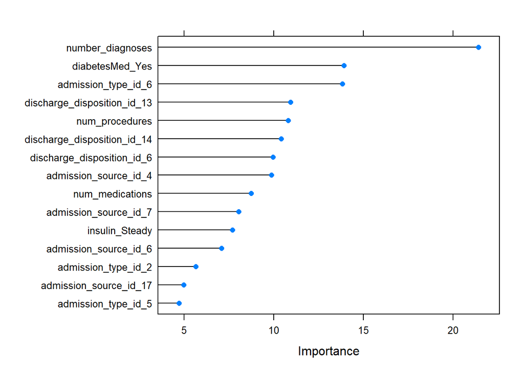

```r
# Importance of the predictors
lrImp <- varImp(lrFit, scale = FALSE)
plot(lrImp, top = 15)
```

#### **3.2 Linear Discriminant Analysis**

```r
# Linear Discriminant Analysis
set.seed(123)
ldaFit <- train(x = trainX,y = trainY,
                method = "lda", metric = "ROC", trControl=ctrl)
#ldaFit
# Calculate training/resampling performance metrics
metrics_tr$LDA <- get_training_metrics(ldaFit)
#metrics_tr

# Predict on test data
ldaTestResults <- predict(ldaFit, testX)

# Calculate test performance metrics
metrics_test$LDA <- get_test_metrics(ldaTestResults)

# Display model performance
cat("LDA (training): accuracy =", metrics_tr$LDA[1], ", sensitivity =", metrics_tr$LDA[2],
    " , specificity =", metrics_tr$LDA[3], ", Precision =", metrics_tr$LDA[4], "\n")
```

```
## LDA (training): accuracy = 0.293 , sensitivity = 0.495  , specificity = 0.663 , Precision = 0.559
```

```r
cat("LDA (test): accuracy =", metrics_test$LDA[1], " , sensitivity =", metrics_test$LDA[2],
    ", specificity =", metrics_test$LDA[3], ", Precision =", metrics_tr$LDA[4], "\n")
```

```
## LDA (test): accuracy = 0.588  , sensitivity = 0.499 , specificity = 0.665 , Precision = 0.559
```

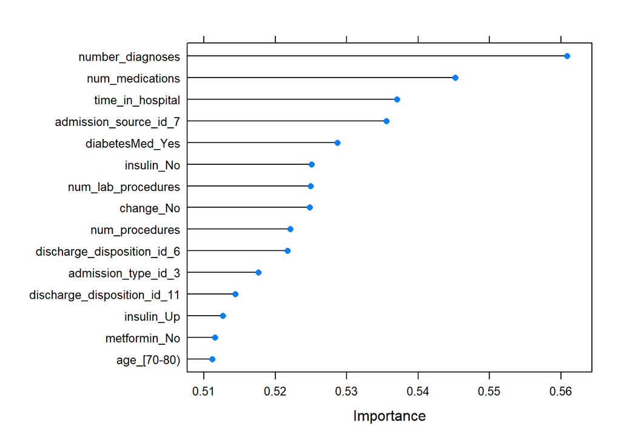

```r
# Importance of the predictors
ldaImp <- varImp(ldaFit, scale = FALSE)
plot(ldaImp, top = 15)
```

#### **3.3 Penalized Logistic Regression Model**

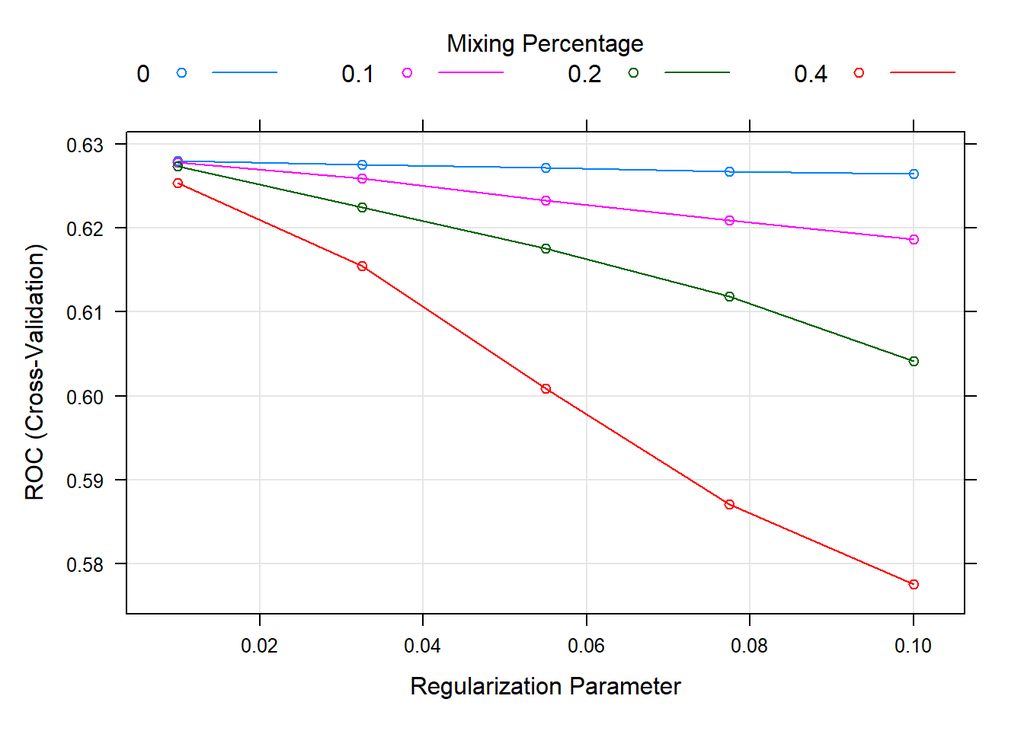

```r
# Penalized Logistic Regression
set.seed(123)
glmnGrid <- expand.grid(alpha=c(0,0.1,0.2,0.4),
                        lambda=seq(.01, .1, length=5))
glmnFit <- train(x = trainX, y = trainY,
                 method="glmnet", tuneGrid=glmnGrid,
                 metric="ROC", trControl=ctrl)
#glmnFit
# Plot the tuning results
plot(glmnFit)
```

```r
# Calculate training/resampling performance metrics
metrics_tr$GLMN <- get_training_metrics(glmnFit)
#metrics_tr

# Predict on test data
glmnTestResults <- predict(glmnFit, testX)

# Calculate test performance metrics
metrics_test$GLMN <- get_test_metrics(glmnTestResults)

# Display model performance
cat("Penalized LR (training): accuracy =", metrics_tr$GLMN[1], ", sensitivity =", metrics_tr$GLMN[2],
    " , specificity =", metrics_tr$GLMN[3], ", Precision =", metrics_tr$GLMN[4], "\n")
```

```
## Penalized LR (training): accuracy = 0.589 , sensitivity = 0.493  , specificity = 0.672 , Precision = 0.565
```

```r
cat("Penalized LR (test): accuracy =", metrics_test$GLMN[1], " , sensitivity =", metrics_test$GLMN[2],
    ", specificity =", metrics_test$GLMN[3], ", Precision =", metrics_tr$GLMN[4], "\n")
```

```
## Penalized LR (test): accuracy = 0.589  , sensitivity = 0.494 , specificity = 0.671 , Precision = 0.565
```

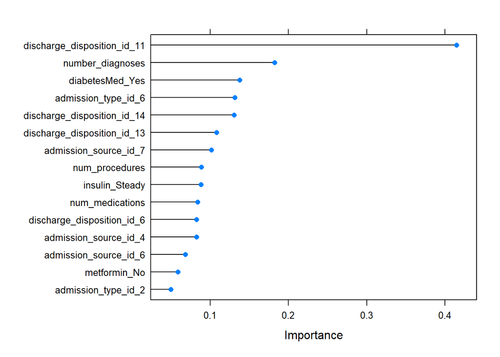

```r
# Importance of the predictors
glmnImp <- varImp(glmnFit, scale = FALSE)
plot(glmnImp, top = 15)
```

#### **3.4 Nearest Shrunken Centroids Model**

```r
# Nearest Shrunken Centroids
set.seed(123)
nscFit <- train(x=trainX,y=trainY,
                method="pam", tuneGrid=data.frame(threshold=seq(0,15, length=20)),
                metric="ROC", trControl=ctrl)
```

```
## 11111111111
```

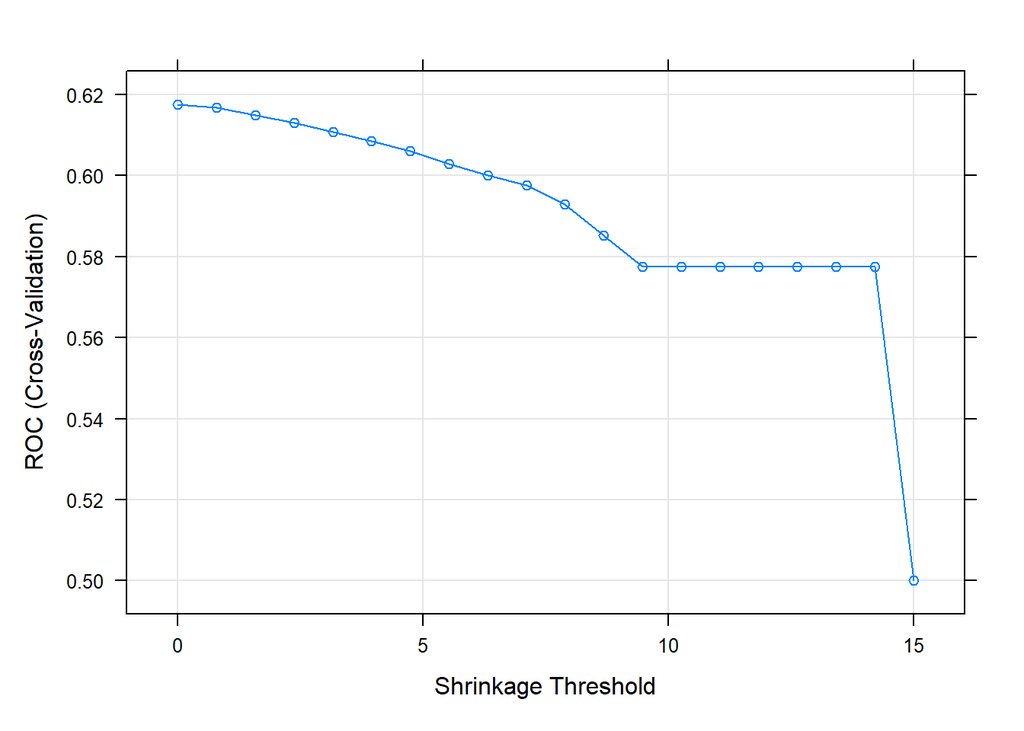

```r
#nscFit

# Plot the tuning result
plot(nscFit)
```

```r
# Calculate training/resampling performance metrics
metrics_tr$NSC <- get_training_metrics(nscFit)

# Predict on test data
nscTestResults <- predict(nscFit, testX)

# Calculate test performance metrics
metrics_test$NSC <- get_test_metrics(nscTestResults)

# Display model performance
cat("NSC (training): accuracy =", metrics_tr$NSC[1], ", sensitivity =", metrics_tr$NSC[2],
    " , specificity =", metrics_tr$NSC[3], ", Precision =", metrics_tr$NSC[4], "\n")
```

```
## NSC (training): accuracy = 0.568 , sensitivity = 0.267  , specificity = 0.827 , Precision = 0.572
```

```r
cat("NSC (test): accuracy =", metrics_test$NSC[1], " , sensitivity =", metrics_test$NSC[2],
    ", specificity =", metrics_test$NSC[3], ", Precision =", metrics_tr$NSC[4], "\n")
```

```
## NSC (test): accuracy = 0.568  , sensitivity = 0.271 , specificity = 0.824 , Precision = 0.572
```

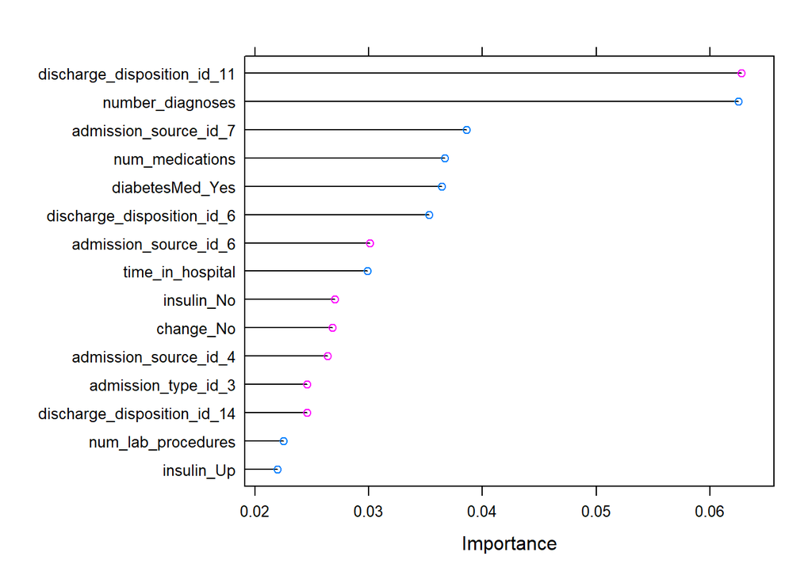

```r
# Importance of the predictors
nscImp <- varImp(nscFit, scale = FALSE)
plot(nscImp, top = 15)
```

#### **3.5 Mixture Discriminant Analysis**

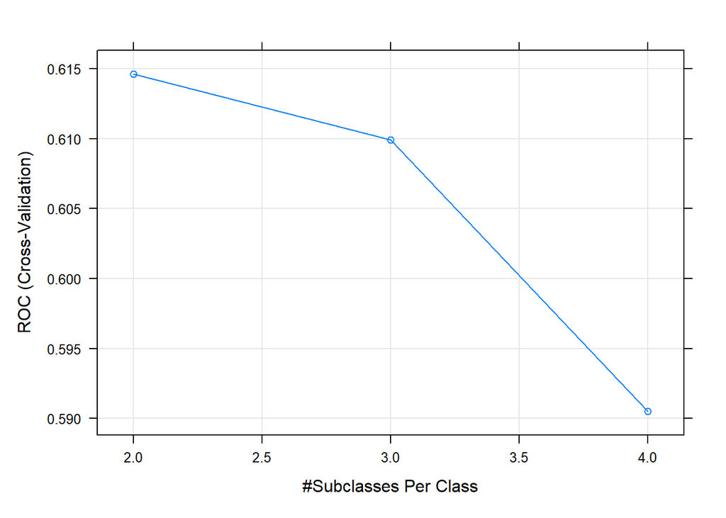

```r
set.seed(123)

mdaFit <- train(x = trainX, y = trainY,
               method = "mda", tuneGrid = expand.grid(subclasses=2:4),
               metric = "ROC", trControl = ctrl)

# Plot the tuning results
plot(mdaFit)
```

```r
# Calculate training/resampling performance metrics
metrics_tr$MDA <- get_training_metrics(mdaFit)
#metrics_tr

# Predict on test data
mdaTestResults <- predict(mdaFit, testX)

# Calculate test performance metrics
metrics_test$MDA <- get_test_metrics(mdaTestResults)

# Display model performance
cat("MDA (training): accuracy =", metrics_tr$MDA[1], ", sensitivity =", metrics_tr$MDA[2],
    " , specificity =", metrics_tr$MDA[3], ", Precision =", metrics_tr$MDA[4], "\n")
```

```
## MDA (training): accuracy = 0.291 , sensitivity = 0.486  , specificity = 0.665 , Precision = 0.556
```

```r
cat("MDA (test): accuracy =", metrics_test$MDA[1], " , sensitivity =", metrics_test$MDA[2],
    ", specificity =", metrics_test$MDA[3], ", Precision =", metrics_tr$MDA[4], "\n")
```

```
## MDA (test): accuracy = 0.589  , sensitivity = 0.498 , specificity = 0.667 , Precision = 0.556
```

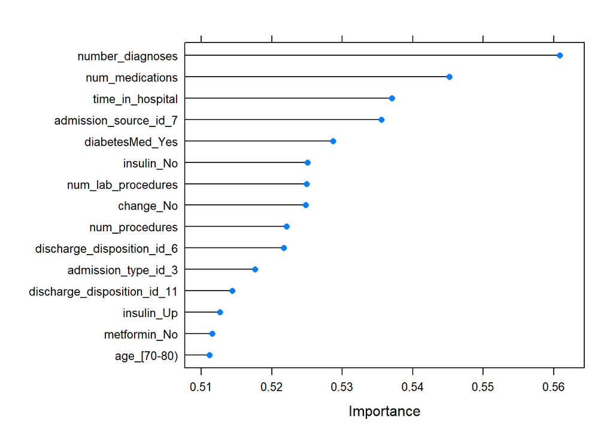

```r
# Importance of the predictors
mdaImp <- varImp(mdaFit, scale = FALSE)
plot(mdaImp, top = 15)
```

#### **3.6 Support Vector Machines**

- Tried, but had to stop running. It is too slow!

```r
# sigmaEst <- kernlab::sigest(as.matrix(trainX))
# svmgrid <- expand.grid(sigma = sigmaEst, C = 2^seq(-2,+2))
#
# set.seed(123)
# svmRFit <- train(x = trainX, y = trainY,
#                 method = "svmRadial", tuneGrid = svmgrid,
#                 metric = "ROC", trControl = ctrl)
# svmRFit
```

### 4. Model Evaluation and Conclusion

#### **4.1 Baseline Model**

```r
round(table(trainY) / length(trainY), 3)
```

```
## trainY
##   YES    NO
## 0.463 0.537
```

- For this data analysis, a model’s ability to predict the positive (readmitted-Yes) accurately is the most important metric. Therefore, we choose All Positive Model as the base model. From the above table, we see that when we assign all predictions as positive, the accuracy of this base model is 0.463.

#### **4.2 Calculate AUC (Area Under ROC Curve)**

```r
#ROC Curve
library(pROC)
lrROC <- roc(response=trainY,predictor=lrFit$pred$YES,levels=rev(levels(lrFit$pred$obs)))
glmnROC <- roc(response=trainY,predictor=glmnFit$pred$YES,levels=rev(levels(glmnFit$pred$obs)))
ldaROC <- roc(response=trainY,predictor=ldaFit$pred$YES,levels=rev(levels(ldaFit$pred$obs)))
nscROC <- roc(response=trainY,predictor=nscFit$pred$YES,levels=rev(levels(nscFit$pred$obs)))
mdaROC <- roc(response=trainY,predictor=mdaFit$pred$YES,levels=rev(levels(nscFit$pred$obs)))

lrAUC <-round(auc(lrROC), 3)
glmnAUC <-round(auc(glmnROC), 3)
ldaAUC <-round(auc(ldaROC), 3)
nscAUC <-round(auc(nscROC), 3)
mdaAUC <-round(auc(mdaROC), 3)

# Get Area under the ROC
metrics_tr <- rbind(metrics_tr, c("AUC", lrAUC, glmnAUC, ldaAUC, nscAUC, mdaAUC))
```

#### **4.3 Compare models’ performance metrics**

- Compare Models’ training (cross-validation) performance

```r
metrics_tr
```

```
##   Metric.Train    LR   LDA  GLMN   NSC   MDA
## 1     Accuracy  0.59 0.293 0.589 0.568 0.291
## 2  Sensitivity   0.5 0.495 0.493 0.267 0.486
## 3  Specificity 0.667 0.663 0.672 0.827 0.665
## 4    Precision 0.564 0.559 0.565 0.572 0.556
## 5          AUC 0.501 0.503 0.503 0.506 0.504
```

- Compare Models’ test performance

```r
metrics_test
```

```
##   Metric.Test    LR   LDA  GLMN   NSC   MDA
## 1    Accuracy 0.588 0.588 0.589 0.568 0.589
## 2 Sensitivity 0.500 0.499 0.494 0.271 0.498
## 3 Specificity 0.663 0.665 0.671 0.824 0.667
## 4   Precision 0.562 0.562 0.565 0.571 0.563
```

#### **4.4 Plot Roc Curves**

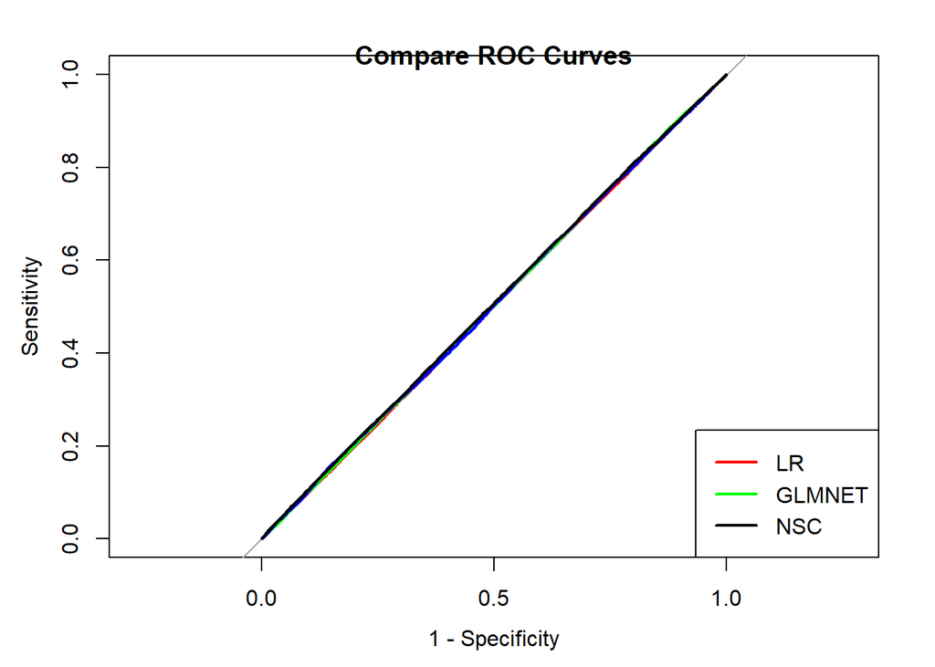

```r
plot(lrROC, type="s", col='red', legacy.axes=TRUE)
plot(glmnROC, type="s", add=TRUE, col='green', legacy.axes=TRUE)
plot(ldaROC, type="s", add=TRUE, col='blue',legacy.axes=TRUE)
plot(nscROC, type="s", add=TRUE, col='black', legacy.axes=TRUE)
legend("bottomright", legend=c("LR", "GLMNET", "NSC"), col=c("red","green", "black"), lwd=2)
title(main="Compare ROC Curves")
```